# Decision Trees, Random Forests e Regressão Logística

```r
library(ggplot2)
library(rattle)
library(rpart)
library(rpart.plot)
library(RColorBrewer)
library(Amelia)
library(randomForest)
```

O objetivo do problema proposto é prever quando uma criança irá nascer com menos de 2,5kg de massa corporal. Para tanto, é utilizado a variável “low” com valores binários: 1 para crianças que nascem com um valor inferior à 2,5kg e 0 para valores maiores que 2,5kg.

```r
dados1 <- read.csv("https://raw.githubusercontent.com/Efsilvaa/EPSMLRepo/master/Data/birthwt.csv")
fatores <- c('low','race','smoke','ht','ui')
dados1[fatores] <- lapply(dados1[fatores], as.factor)

summary(dados1)
```

```
##        X         low          age             lwt        race   smoke
##  Min.   :  4.0   0:130   Min.   :14.00   Min.   : 80.0   1:96   0:115
##  1st Qu.: 68.0   1: 59   1st Qu.:19.00   1st Qu.:110.0   2:26   1: 74
##  Median :123.0           Median :23.00   Median :121.0   3:67
##  Mean   :121.1           Mean   :23.24   Mean   :129.8
##  3rd Qu.:176.0           3rd Qu.:26.00   3rd Qu.:140.0
##  Max.   :226.0           Max.   :45.00   Max.   :250.0
##       ptl         ht      ui           ftv              bwt
##  Min.   :0.0000   0:177   0:161   Min.   :0.0000   Min.   : 709
##  1st Qu.:0.0000   1: 12   1: 28   1st Qu.:0.0000   1st Qu.:2414
##  Median :0.0000                   Median :0.0000   Median :2977
##  Mean   :0.1958                   Mean   :0.7937   Mean   :2945
##  3rd Qu.:0.0000                   3rd Qu.:1.0000   3rd Qu.:3487
##  Max.   :3.0000                   Max.   :6.0000   Max.   :4990
```

A funçao missmap da library Amelia é utilizada para identificar os missing values.

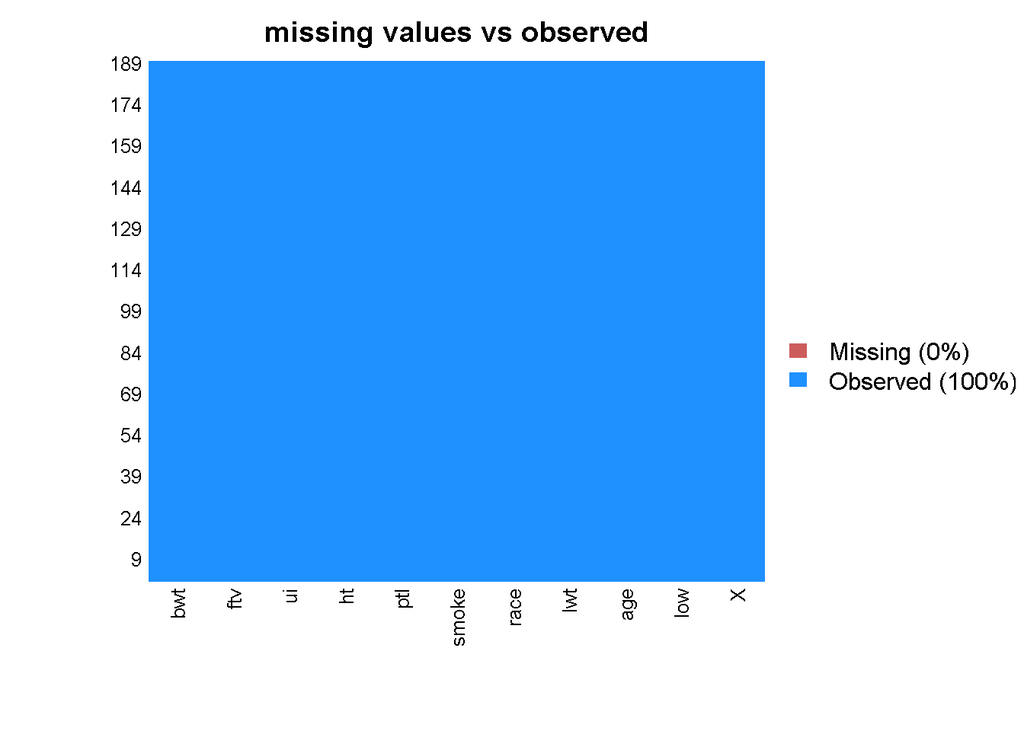

```r
missmap(dados1,main="missing values vs observed")
```

Como não há valores faltantes podemos dar continuidade à construção dos modelos.

Visualização dos dados:

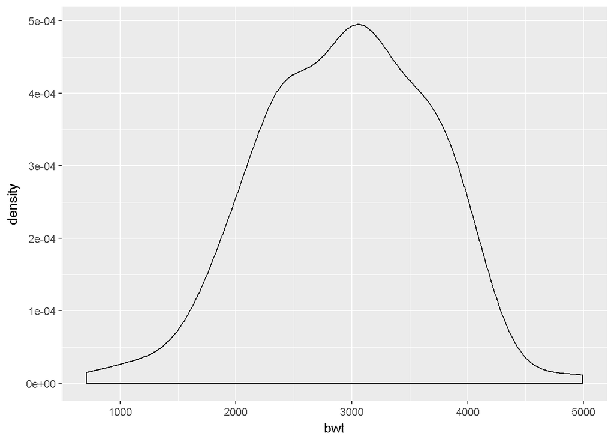

```r
plot1 <- ggplot(data=dados1, aes(bwt))+geom_density()
plot1
```

Os dados são entao divididos em dados de treino e dados de teste.

```r
train.index <- sample((nrow(dados1)), 0.7*nrow(dados1))
train <- dados1[train.index,]
test <- dados1[-train.index,]
```

1º Modelo - Decision Trees

```r
decisiontree <- rpart(data=train, low ~ race + smoke + ht + ui + age + lwt + ftv, method = "class" )
summary(decisiontree)
```

```
## Call:
## rpart(formula = low ~ race + smoke + ht + ui + age + lwt + ftv,
##     data = train, method = "class")
##   n= 132
##
##           CP nsplit rel error   xerror      xstd
## 1 0.04054054      0 1.0000000 1.000000 0.1394678
## 2 0.01351351      3 0.8648649 1.459459 0.1526706
## 3 0.01000000      5 0.8378378 1.459459 0.1526706
##
## Variable importance
## smoke   lwt   age    ui  race
##    42    26    18    13     1
##
## Node number 1: 132 observations,    complexity param=0.04054054
##   predicted class=0  expected loss=0.280303  P(node) =1
##     class counts:    95    37
##    probabilities: 0.720 0.280
##   left son=2 (84 obs) right son=3 (48 obs)
##   Primary splits:
##       smoke splits as  LR,        improve=3.727814, (0 missing)
##       age   < 27.5  to the right, improve=3.156566, (0 missing)
##       ui    splits as  LR,        improve=2.686546, (0 missing)
##       lwt   < 112.5 to the right, improve=2.094100, (0 missing)
##       ftv   < 0.5   to the right, improve=1.732386, (0 missing)
##   Surrogate splits:
##       lwt  < 94.5  to the right, agree=0.689, adj=0.146, (0 split)
##       race splits as  RLL,       agree=0.644, adj=0.021, (0 split)
##
## Node number 2: 84 observations
##   predicted class=0  expected loss=0.1904762  P(node) =0.6363636
##     class counts:    68    16
##    probabilities: 0.810 0.190
##
## Node number 3: 48 observations,    complexity param=0.04054054
##   predicted class=0  expected loss=0.4375  P(node) =0.3636364
##     class counts:    27    21
##    probabilities: 0.562 0.438
##   left son=6 (39 obs) right son=7 (9 obs)
##   Primary splits:
```

[output cut: 51 more lines]

```
##       age < 24    to the right, improve=1.0560440, (0 missing)
##       lwt < 141   to the left,  improve=0.6000000, (0 missing)
##       ftv < 1.5   to the right, improve=0.2666667, (0 missing)
##   Surrogate splits:
##       lwt < 116   to the right, agree=0.7, adj=0.143, (0 split)
##
## Node number 50: 13 observations
##   predicted class=0  expected loss=0.2307692  P(node) =0.09848485
##     class counts:    10     3
##    probabilities: 0.769 0.231
##
## Node number 51: 7 observations
##   predicted class=1  expected loss=0.4285714  P(node) =0.0530303
##     class counts:     3     4
##    probabilities: 0.429 0.571
```

[figure not shown]

```r
fancyRpartPlot(decisiontree)
```

```r
prediction <- predict(decisiontree, test, type="class")
table(prediction, test$low)
```

```
##
## prediction  0  1
##          0 27 15
##          1  8  7
```

```r
prop.table(table(prediction, test$low))
```

```
##
## prediction         0         1
##          0 0.4736842 0.2631579
##          1 0.1403509 0.1228070
```

2º Modelo - Random Forests

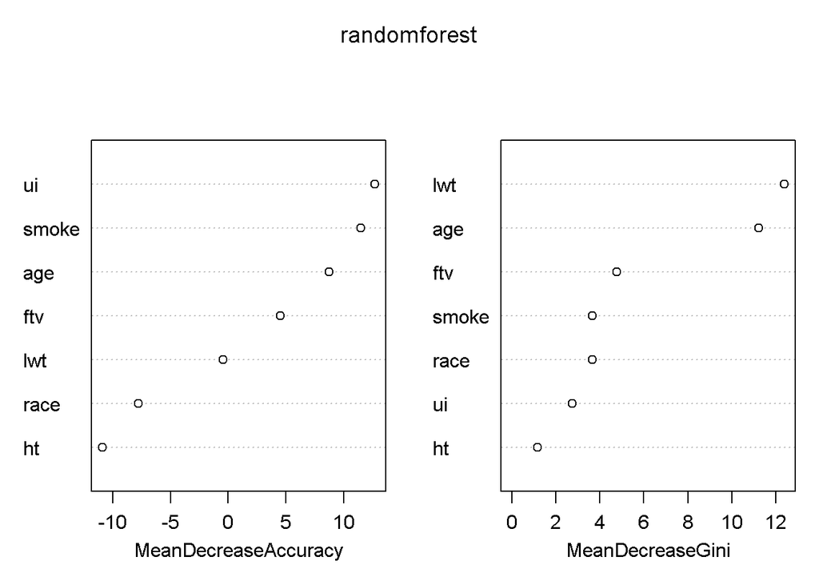

```r
randomforest <- randomForest(data=train, low ~ race + smoke + ht + ui + age + lwt + ftv, importance = TRUE, ntree=3000)
varImpPlot(randomforest)
```

```r
prediction1 <- predict(randomforest, test, type="class")
table(prediction1, test$low)
```

```
##
## prediction1  0  1
##           0 31 16
##           1  4  6
```

```r
prop.table(table(prediction1,test$low))
```

```
##
## prediction1          0          1
##           0 0.54385965 0.28070175
##           1 0.07017544 0.10526316
```

3º Modelo - Regressão Logística

```r
reglog <- glm(data=train, low ~ race + smoke + ht + ui + age + lwt + ftv, family = binomial(link = "logit") )
summary(reglog)
```

```
##
## Call:
## glm(formula = low ~ race + smoke + ht + ui + age + lwt + ftv,
##     family = binomial(link = "logit"), data = train)
##
## Deviance Residuals:
##     Min       1Q   Median       3Q      Max
## -1.6525  -0.7678  -0.4418   0.7958   2.2940
##
## Coefficients:
##              Estimate Std. Error z value Pr(>|z|)
## (Intercept)  1.133248   1.511430   0.750  0.45338
## race2        1.696837   0.681798   2.489  0.01282 *
## race3        0.743025   0.579681   1.282  0.19992
## smoke1       1.477203   0.523366   2.823  0.00477 **
## ht1          1.195008   0.941302   1.270  0.20425
## ui1          1.015717   0.574704   1.767  0.07717 .
## age         -0.063561   0.046517  -1.366  0.17182
## lwt         -0.015684   0.008654  -1.812  0.06995 .
## ftv         -0.059336   0.229407  -0.259  0.79591
## ---
## Signif. codes:  0 '***' 0.001 '**' 0.01 '*' 0.05 '.' 0.1 ' ' 1
##
## (Dispersion parameter for binomial family taken to be 1)
##
##     Null deviance: 156.62  on 131  degrees of freedom
## Residual deviance: 127.63  on 123  degrees of freedom
## AIC: 145.63
##
## Number of Fisher Scoring iterations: 5
```

```r
anova(reglog, test="Chisq")
```

```
## Analysis of Deviance Table
##
## Model: binomial, link: logit
##
## Response: low
##
## Terms added sequentially (first to last)
##
##
##       Df Deviance Resid. Df Resid. Dev Pr(>Chi)
## NULL                    131     156.62
## race   2   3.0478       129     153.57 0.217861
## smoke  1  13.2402       128     140.33 0.000274 ***
## ht     1   0.2457       127     140.08 0.620095
## ui     1   5.0021       126     135.08 0.025317 *
## age    1   3.2635       125     131.82 0.070836 .
## lwt    1   4.1154       124     127.70 0.042494 *
## ftv    1   0.0677       123     127.63 0.794741
## ---
## Signif. codes:  0 '***' 0.001 '**' 0.01 '*' 0.05 '.' 0.1 ' ' 1
```

```r
prediction_prob <- predict(reglog, newdata=test,type='response')
prediction2 <- ifelse(prediction_prob>0.5,1,0)
table(prediction2,test$low)
```

```
##
## prediction2  0  1
##           0 28 18
##           1  7  4
```

```r
prop.table(table(prediction2,test$low))
```

```
##
## prediction2          0          1
##           0 0.49122807 0.31578947
##           1 0.12280702 0.07017544
```